```python
from sklearn.svm import SVR
import numpy as np
import pandas as pd
import matplotlib as mpl
import matplotlib.pyplot as plt
import seaborn as sns
from sklearn.preprocessing import MinMaxScaler
from sklearn.pipeline import make_pipeline
from sklearn.metrics import mean_squared_error
from sklearn.model_selection import cross_val_score, train_test_split
from sklearn.grid_search import GridSearchCV

%matplotlib notebook
```

# Machine learning semiconductor band gaps

#### Leigh weston, July 2017

The band gap is the fundamental property for a semiconductor, particularly for photovoltaics applications. Quaternary semiconductors with general formula I2-II-IV-VI4 are promising solar absorbers, however there are thousands of possible cation-anion comibations; this is far too many to perform accurate quantum mechanical caluclations on.

I have performed accurate quantum mechanical calculations on a subset (n = 200) of these materials, and used the results to train a machine learning model. The trained model can be used to predict the band gaps of 1568 possible I2-II-IV-VI4 semiconductors.

I tried a number of machine learning aglorithms for regression, including support vector machines, decision trees, and tree-based enemble methods. For determining the magnitude of the fundamental gap, support vector regression with a radial bias kernel performed the best, and this method is used below.

## Organising the data

The first step is to organize the data and set up the descriptors for fitting.

Each I2-II-IV-VI4 compound has four elements; 3 cations with valence I, II, and IV, and one anion with valence VI. For descriptors, I am using simple, element-specific features. I am using the electronegativity, ionic radius, and row in the periodic table; for the cations, I also use the column in the perodic table. There are 15 descriptors in total (4 for each cation, 3 for the anion).

#### Set up the descriptors

Below I define a function gen_x() that returns the features for a given I2-II-IV-VI4 compound.

The input is a list of the cations and and anions in the compound, ['I', 'II', 'IV',, 'VI']; gen_x() returns the 15-dimensional vector of features for the compound.

```python
###Valence 1
Li = { 'el_1_row' : 2, 'el_1_col' : 1,  'el_1_rad': 0.590, 'el_1_neg': 0.980 }
Na = { 'el_1_row' : 3, 'el_1_col' : 1,  'el_1_rad': 0.990, 'el_1_neg': 0.930 }
K  = { 'el_1_row' : 4, 'el_1_col' : 1,  'el_1_rad': 1.370, 'el_1_neg': 0.820 }
Rb = { 'el_1_row' : 5, 'el_1_col' : 1,  'el_1_rad': 1.520, 'el_1_neg': 0.820 }
Cs = { 'el_1_row' : 6, 'el_1_col' : 1,  'el_1_rad': 1.670, 'el_1_neg': 0.790 }
Cu = { 'el_1_row' : 4, 'el_1_col' : 11, 'el_1_rad': 0.600, 'el_1_neg': 1.900 }
Ag = { 'el_1_row' : 5, 'el_1_col' : 11, 'el_1_rad': 0.600, 'el_1_neg': 1.000 }

###Valence 3
Be = { 'el_2_row' : 2, 'el_2_col' : 2,  'el_2_rad': 0.270, 'el_2_neg': 1.570 }
Mg = { 'el_2_row' : 3, 'el_2_col' : 2,  'el_2_rad': 0.570, 'el_2_neg': 1.310 }
Ca = { 'el_2_row' : 4, 'el_2_col' : 2,  'el_2_rad': 1.000, 'el_2_neg': 1.000 }
Sr = { 'el_2_row' : 5, 'el_2_col' : 2,  'el_2_rad': 1.180, 'el_2_neg': 0.950 }
Ba = { 'el_2_row' : 6, 'el_2_col' : 2,  'el_2_rad': 1.350, 'el_2_neg': 0.890 }
Zn = { 'el_2_row' : 4, 'el_2_col' : 12, 'el_2_rad': 0.600, 'el_2_neg': 1.650 }
Cd = { 'el_2_row' : 5, 'el_2_col' : 12, 'el_2_rad': 0.780, 'el_2_neg': 1.690 }
Hg = { 'el_2_row' : 6, 'el_2_col' : 12, 'el_2_rad': 0.960, 'el_2_neg': 2.000 }

###Valence 4
C  = { 'el_4_row' : 2, 'el_4_col' : 14, 'el_4_rad': 0.150, 'el_4_neg': 2.550 }
Si = { 'el_4_row' : 3, 'el_4_col' : 14, 'el_4_rad': 0.260, 'el_4_neg': 1.900 }
Ge = { 'el_4_row' : 5, 'el_4_col' : 14, 'el_4_rad': 0.390, 'el_4_neg': 2.010 }
Sn = { 'el_4_row' : 6, 'el_4_col' : 14, 'el_4_rad': 0.550, 'el_4_neg': 1.960 }
Ti = { 'el_4_row' : 4, 'el_4_col' :  4, 'el_4_rad': 0.420, 'el_4_neg': 1.540 }
Zr = { 'el_4_row' : 5, 'el_4_col' :  4, 'el_4_rad': 0.590, 'el_4_neg': 1.333 }
Hf = { 'el_4_row' : 6, 'el_4_col' :  4, 'el_4_rad': 0.580, 'el_4_neg': 1.300 }

###Valence 6
O =  { 'el_6_row' : 2, 'el_6_rad': 1.380, 'el_6_neg': 3.440 }
S =  { 'el_6_row' : 3, 'el_6_rad': 1.840, 'el_6_neg': 2.580 }
Se = { 'el_6_row' : 4, 'el_6_rad': 1.980, 'el_6_neg': 2.550 }
Te = { 'el_6_row' : 3, 'el_6_rad': 2.210, 'el_6_neg': 2.100 }

def gen_x(material_array):
    z = {}
    for material in material_array:
        z.update(eval(material))

    return pd.Series(z)
```

#### Read in and clean the data

Using quantum mechanical calculations based on density-functional theory, I have calculated the band gap and lattice parameters for 200 I2-II-IV-VI4 semiconductors. A list of materials for which I performed tha calculation is saved in a file called 'MATERIALS_LIST'; the calculated band gaps and lattice constants are save in the files 'BAND_GAPS' and 'LATTICE_CONSTANTS', respectively.

Below the data is read in and cleaned. Next, the data is put into a pandas data frame.

```python
##Read in band gaps

f_gaps = open('BAND_GAPS', 'r')
gaps_data = f_gaps.readlines()
f_gaps.close()

band_gaps = [float(i.split(',')[-2].rstrip()) for i in gaps_data[1:]]
direct_gaps = [float(i.split(',')[-1].rstrip()) for i in gaps_data[1:]]

#Read in materials

f_mater = open('MATERIALS_LIST', 'r')
materials =  [eval(i.rstrip()) for i in f_mater]
f_mater.close()

#Read in lattice constant

f_latt = open('LATTICE_CONSTANTS', 'r')
a_const, c_const = [], []
for i in f_latt.readlines()[1:]:
    a_const.append(float(i.split(',')[-2]))
    c_const.append(float(i.split(',')[-1]))
f_latt.close()


#Get the features for each compound, add into a dataframe

df_data = pd.DataFrame()
for m in materials:
    df_data = pd.concat([df_data, gen_x(m)], axis = 1)

#Tidy up the dataframe, add the band gaps.

df_data = df_data.transpose()
mater_new = ['{}2{}{}{}4'.format(*i) for i in materials]
df_data['Material'] = mater_new
df_data.set_index(['Material'], inplace=True)
df_data['a (Angst.)'] = a_const
df_data['c (Angst.)'] = c_const
df_data['Band gaps (eV)'] = band_gaps
df_data['Direct gaps (eV)'] = direct_gaps
df_data = df_data[ df_data['Band gaps (eV)'] > 0 ]

#Save dataframe to .csv
df_data.to_csv('quaternary_database.csv')
```

Once I read in the data, I noticed that some of the materials did not have a band gap - this would really mess up the fitting, so I removed them. There 1re 184 materials left.

I save the data frame to .csv for safe keeping.

The dataframe contains the band gaps for each compound, as well as the vector of features. This is ready to use for fitting a machine learning model.

## Band gap regressor: Support vector machine with RBF

Before fitting the model, the first step is to read the .csv file into a dataframe.

```python
df = pd.read_csv('quaternary_database.csv', index_col = 'Material')
df.head()
```

| Material | el_1_col | el_1_neg | el_1_rad | el_1_row | el_2_col | el_2_neg | el_2_rad | el_2_row | el_4_col | el_4_neg | el_4_rad | el_4_row | el_6_neg | el_6_rad | el_6_row | a (Angst.) | c (Angst.) | Band gaps (eV) | Direct gaps (eV) |
| --- | --- | --- | --- | --- | --- | --- | --- | --- | --- | --- | --- | --- | --- | --- | --- | --- | --- | --- | --- |
| Li2CdGeSe4 | 1.0 | 0.98 | 0.59 | 2.0 | 12.0 | 1.69 | 0.78 | 5.0 | 14.0 | 2.010 | 0.39 | 5.0 | 2.55 | 1.98 | 4.0 | 5.915 | 11.248 | 2.673 | 2.673 |
| Cs2BeZrSe4 | 1.0 | 0.79 | 1.67 | 6.0 | 2.0 | 1.57 | 0.27 | 2.0 | 4.0 | 1.333 | 0.59 | 5.0 | 2.55 | 1.98 | 4.0 | 7.155 | 10.315 | 2.941 | 2.941 |
| Cu2SrGeSe4 | 11.0 | 1.90 | 0.60 | 4.0 | 2.0 | 0.95 | 1.18 | 5.0 | 14.0 | 2.010 | 0.39 | 5.0 | 2.55 | 1.98 | 4.0 | 5.802 | 11.816 | 0.935 | 0.935 |
| K2BeCSe4 | 1.0 | 0.82 | 1.37 | 4.0 | 2.0 | 1.57 | 0.27 | 2.0 | 14.0 | 2.550 | 0.15 | 2.0 | 2.55 | 1.98 | 4.0 | 6.656 | 7.957 | 2.893 | 2.927 |
| Rb2BeHfO4 | 1.0 | 0.82 | 1.52 | 5.0 | 2.0 | 1.57 | 0.27 | 2.0 | 4.0 | 1.300 | 0.58 | 6.0 | 3.44 | 1.38 | 2.0 | 5.651 | 8.089 | 5.098 | 5.098 |

I initially calculated the direct and indirect gaps, as well as the lattice constants. At this point I am only interested in fitting the fundamental gap (2nd last column of data frame).

Here i will extract the features and gaps for fitting.

```python
X = df.iloc[:, :15].as_matrix()
y = df.iloc[:,-2]
```

#### Default parameters

At first, I just want to get a feeling for how well the model works with default parameters, so I randomly select 75% of the data to train a support vector regressor with a radial bias kernel; the remaining 25% of the data can be used to verify the accuracy of the predictions.

Support vector machines fit a hyperplane in a multidimensional space; in regression, there is a hyperplane margin as well as a radial bias function. The distance between two points is defined as the Euclidean distance and so it is important to properly scale the features. I use the MinMaxScaler here.

```python
#Regression on train_test_split - default C and gamma parameter
X_train, X_test, y_train, y_test = train_test_split(X, y)
scaler = MinMaxScaler().fit(X_train)
X_train_transformed = scaler.transform(X_train)
X_test_transformed = scaler.transform(X_test)
svr_rbf = SVR().fit(X_train_transformed, y_train)

print('Mean squared error on training set: {}'.format(mean_squared_error(y_train, svr_rbf.predict(X_train_transformed))))
print('Mean squared error on test set: {}'.format(mean_squared_error(y_test, svr_rbf.predict(X_test_transformed))))
```

```
Mean squared error on training set: 0.35629952742708415
Mean squared error on test set: 0.3076917387429432
```

Since I am using the MinMaxScaler, I can make a pipeline to use with the cross validation.

```python
#5-fold cross validation - default C and gamma parameter
pipe = make_pipeline(MinMaxScaler(), SVR())
cv_scores = cross_val_score(pipe, X, y, cv=10, scoring='neg_mean_squared_error')

print('5-fold cross validation scores: {}'.format(cv_scores))
print('Mean cv score: {}'.format(cv_scores.mean()))
```

```
5-fold cross validation scores: [-0.08722408 -0.75204854 -0.42470889 -0.25935694 -0.64266291 -0.76646513
 -0.32166163 -0.12700668 -0.26572429 -0.19538358]
Mean cv score: -0.3842242678322499
```

#### Optimise parameters

I can do a grid search over $C$ and $\gamma$.

At first, I do a coarse grid search over a wide range using 10-fold cross validation.

```python
#Grid search to optimize the parameters
params = [{'svr__C': np.logspace(-4, 4, 9), 'svr__gamma': np.logspace(-4, 4, 9)}]
pipe = make_pipeline(MinMaxScaler(), SVR())
svr_gs = GridSearchCV(pipe, params, cv=10, scoring='neg_mean_squared_error')
grid_search = svr_gs.fit(X, y)
```

```python
print('RBF best params: {}'.format(grid_search.best_params_))
print('RBF best score: {}'.format(grid_search.best_score_))
```

```
RBF best params: {'svr__gamma': 0.10000000000000001, 'svr__C': 100.0}
RBF best score: -0.08165700151523134
```

The grid search found $C = 100$ and $\gamma = 0.1$ gives the best results. I can do a finer search closer to these values to make sure that the parmaters are best optimized.

```python
params = [{'svr__C': np.logspace(-0, 4, 20), 'svr__gamma': np.logspace(-3, 1, 20)}]
pipe = make_pipeline(MinMaxScaler(), SVR())
svr_gs = GridSearchCV(pipe, params, cv=10, scoring='neg_mean_squared_error')
grid_search = svr_gs.fit(X, y)
```

```python
print('RBF best params: {}'.format(grid_search.best_params_))
print('RBF best score: {}'.format(grid_search.best_score_))
```

```
RBF best params: {'svr__gamma': 0.12742749857031335, 'svr__C': 127.42749857031335}
RBF best score: -0.07975824202479488
```

Using grid search, I identified that $C = 127.4$ and $\gamma = 0.127$ are optimum parameters for our model.

#### Optimized predictions

With the model now optimized, I can make preditions on the training and test set. We can quickly check the RMSE on the training and test set to make sure that everything is working.

```python
svr_rbf_opt = SVR(C = 127.4, gamma = 0.127).fit(X_train_transformed, y_train)

print('Mean squared error on training set: {}'.format(mean_squared_error(y_train, svr_rbf_opt.predict(X_train_transformed))))
print('Mean squared error on test set: {}'.format(mean_squared_error(y_test, svr_rbf_opt.predict(X_test_transformed))))
```

```
Mean squared error on training set: 0.008435319158154408
Mean squared error on test set: 0.055844616106433126
```

#### Plot predictions

Time to plot the results of the model.

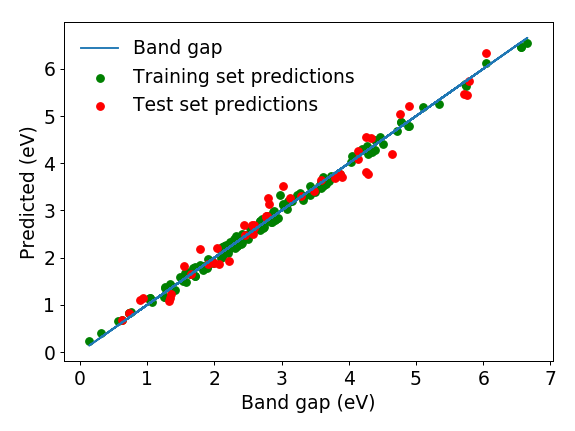

```python
plt.figure()
plt.plot(y, y)
plt.scatter(y_train, svr_rbf_opt.predict(X_train_transformed), color = 'g')
plt.scatter(y_test, svr_rbf_opt.predict(X_test_transformed), color = 'r')
axes = plt.gca()
axes.set_xlabel('Band gap (eV)')
axes.set_ylabel('Predicted (eV)')
plt.legend(['Band gap', 'Training set predictions', 'Test set predictions'], frameon = False)
mpl.rcParams.update({'font.size': 15})
plt.tight_layout()
plt.savefig('SVR_RBF.png')
```

## Predicting band gaps for new materials

Now that I have a good working model, I can predict the band gaps for all 1568 semiconductors. The first thing to do is to loop through all of the possible cation-anion combinations and create a list for all materials.

```python
ones = [ 'Li', 'Na', 'K', 'Rb', 'Cs', 'Cu', 'Ag' ]
twos = [ 'Be', 'Mg', 'Ca', 'Sr', 'Ba', 'Zn', 'Cd', 'Hg' ]
fours = [ 'C', 'Si', 'Ge', 'Sn', 'Ti', 'Zr', 'Hf' ]
sixes = [ 'O', 'S', 'Se', 'Te']

all_materials = [[i, j, k, l] for i in ones for j in twos for k in fours for l in sixes]
```

Each possible combination is sent to the function gen_x() to create the series object for the features of that compound. The features for each compound are appended into a dataframe.

```python
df_all = pd.DataFrame()
for m in all_materials:
    df_all = pd.concat([df_all, gen_x(m)], axis = 1)

df_all = df_all.transpose()
df_all['Material'] = ['{}2{}{}{}4'.format(*i) for i in all_materials]
df_all.set_index('Material', inplace = True)
df_all.head()
```

| Material | el_1_col | el_1_neg | el_1_rad | el_1_row | el_2_col | el_2_neg | el_2_rad | el_2_row | el_4_col | el_4_neg | el_4_rad | el_4_row | el_6_neg | el_6_rad | el_6_row |
| --- | --- | --- | --- | --- | --- | --- | --- | --- | --- | --- | --- | --- | --- | --- | --- |
| Li2BeCO4 | 1.0 | 0.98 | 0.59 | 2.0 | 2.0 | 1.57 | 0.27 | 2.0 | 14.0 | 2.55 | 0.15 | 2.0 | 3.44 | 1.38 | 2.0 |
| Li2BeCS4 | 1.0 | 0.98 | 0.59 | 2.0 | 2.0 | 1.57 | 0.27 | 2.0 | 14.0 | 2.55 | 0.15 | 2.0 | 2.58 | 1.84 | 3.0 |
| Li2BeCSe4 | 1.0 | 0.98 | 0.59 | 2.0 | 2.0 | 1.57 | 0.27 | 2.0 | 14.0 | 2.55 | 0.15 | 2.0 | 2.55 | 1.98 | 4.0 |
| Li2BeCTe4 | 1.0 | 0.98 | 0.59 | 2.0 | 2.0 | 1.57 | 0.27 | 2.0 | 14.0 | 2.55 | 0.15 | 2.0 | 2.10 | 2.21 | 3.0 |
| Li2BeSiO4 | 1.0 | 0.98 | 0.59 | 2.0 | 2.0 | 1.57 | 0.27 | 2.0 | 14.0 | 1.90 | 0.26 | 3.0 | 3.44 | 1.38 | 2.0 |

#### Fitting the gaps

This data frame contains all of the features to fit the band gaps. First I convert it to an array; next, I have to transform the features using the previosly fitted MinMaxScaler.

After that, I can finally fit the gaps. I will save the results for safe keeping.

```python
X_all = df_all.as_matrix()
X_all_transformed = scaler.transform(X_all)
df_all['Band gap (eV)'] = svr_rbf_opt.predict(X_all_transformed)
df_all.to_csv('ALL_GAPS.csv')
```

#### Analyze and save the results

It is worth plotting the predicted gaps for the materials with different anions to see how the band gap spans the visible spectrum (we are interested in photovoltaic materials, after all).

In order to plot the results for the different anions, I need to extract the gaps for the oxides, sulfides, selenides and tellurides separately.

```python
oxides     = df_all[ df_all.index.str[-2:]  == 'O4' ].iloc[:, -1]
sulfides   = df_all[ df_all.index.str[-2:]  == 'S4' ].iloc[:, -1]
selenides  = df_all[ df_all.index.str[-3:]  == 'Se4' ].iloc[:, -1]
tellurides = df_all[ df_all.index.str[-3:]  == 'Te4' ].iloc[:, -1]
```

The gaps for each class of materials are best visualized using a violin plot.

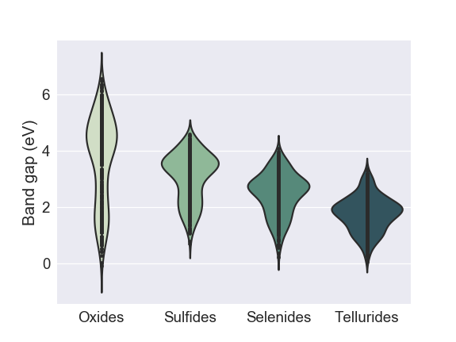

```python
sns.set(font_scale=1.5)
pal = sns.cubehelix_palette(4, rot=-.5, dark=.3)
ax = sns.violinplot(data= [ oxides, sulfides, selenides, tellurides ], palette=pal, inner="points")
ax.set_xticklabels(['Oxides', 'Sulfides', 'Selenides', 'Tellurides'])
ax.set_ylabel('Band gap (eV)')
plt.savefig('all_gaps.png')
```

Clear trends can be observed in the band gap properties upon exchange of the anion. The oxides have the largest band gaps, however are there is a larger spread in the band gap values. There is a clear trend moving down the periodic table: the band gap is smaller, and the distribution is more bunched. The tellurides have the smallest band gaps, and the most localized distribution.

Importantly, many of the compounds have a band gap around 1.5 eV, which is the optimum value for photovoltaics applications.

```python
n_opt = sum([int(i) for i in (df_all['Band gap (eV)'] > 1.2) & (df_all['Band gap (eV)'] < 1.8)])
n_around = sum([int(i) for i in (df_all['Band gap (eV)'] > 0.5) & (df_all['Band gap (eV)'] < 2.5)])
print('The number of materials discovered with gaps at the optimum value: {}'.format(n_opt))
print('The number of materials discovered with gaps around the optimum range: {}'.format(n_around))
```

```
The number of materials discovered with gaps at the optimum value: 242
The number of materials discovered with gaps around the optimum range: 717
```

## Conclusion

Support vector regression worked remarkably well in the prediction of semiconductor band gaps. I was able to predict the gaps of 1568 materials to a high degree of accuracy; many of these materials have never been studied before.

I was able to identiy around 242 materials with band gaps close to the optimum value for photovoltaics applications.